# Algoritmos de clustering

UOC - Master BI - Business Analytics Miguel Nicolas Rodriguez Martinez

Mayo del 2018

# 1 Introducción

Esta práctica está basada en los puntos 3.3.1, 3.3.2 y 3.3.3 del material didáctico (Business Analytics) de la asignatura. En el punto 3.3.1 se explica el procedimiento de segmentación jerárquica, mientras en los puntos 3.3.2 y 3.3.3 se explican procedimientos de segmentación no jerárquica para la formación de grupos que, respecto a la información utilizada, sean homogéneos dentro de si mismos y heterogéneos entre unos y otros.

A lo largo de la práctica se proponen una serie de representaciones gráficas que ayudan a la interpretación de los resultados, sin embargo, podéis insertar más visualizaciones de las propuestas o incluso más código del estrictamente exigido en los ejercicios, eso sí, siempre con el objetivo de completar y mejorar el estudio propuesto.

En esta práctica importaremos los datos desde un fichero de texto .csv con los campos delimitados por “;”. Dichos datos corresponden a la información sobre algunas características de una muestra de asegurados procedentes de una cartera de seguros de automóvil. Los datos han sido extraídos de una cartera de asegurados real, aunque para garantizar la confidencialidad de la información se ha seleccionado una muestra no representativa o sesgada de la realidad.

# 2 Objetivos e información disponible

El objetivo de esta segunda PEC se centra en la determinación de distintos perfiles de asegurados del automóvil.

Las variables que se definen en la base de datos y sus contenidos son:

–poliza: Identificador de póliza

–Sexo: Sexo del cliente

–sri: Situación de riesgo o zona de circulación urbana o no urbana

–gdi: Contratada garantía de daños propios o no

–sin: Número de siniestros en el año analizado

–ant_comp: Antigüedad del cliente en la compañía (en años)

–ant_perm: Antigüedad del permiso de conducir del asegurado (en años)

–edad: Edad del asegurado (en años)

–ant_veh: Antigüedad del vehículo asegurado (en años).

# 3 Apartados de la práctica

El código R que utilizaremos en la práctica se divide en apartados según las tareas que iremos realizando:

- Directorio de trabajo
- Importación del fichero de datos .csv. Manipulación y representación de las variables
- Normalización de atributos
- Agrupación jerárquica: Algoritmo aglomerativo
- Uso de la función hclust() para la aglomeración de elementos
- Representación gráfica, Dendograma
- Asignación de los clusters
- Representación de los cluster
- Representación gráfica de variables por cluster
- Agrupación no jerárquica: Algoritmo kmeans
- Uso de la función kmeans() para la formación de cluster (grupos o perfiles de individuos)
- Elección del número de clústers
- Asignación de los clusters
- Representación de los cluster
- Representación gráfica de los clústers
- Ejercicios PEC2: Análisis cluster

# 4 Directorio de trabajo

Antes de pasar a la importación y análisis de los datos definimos un directorio de trabajo o carpeta donde tenéis guardado el fichero de datos. Recordad que si abrís el RStudio desde vuestro directorio de trabajo, pulsando sobre el fichero .RMD que se os proporciona como parte del enunciado, este paso no haría falta.

```r
#setwd("Pon aquí el directorio utilizado")
#Cambiar el argumento de setwd() con vuestro directorio, recordad utilizad las barras /.
setwd("/home/miguelnrm/code/msc.assignment/business")
```

# 5 Importación del fichero de datos .csv. Manipulación y representación de las variables.

En primer lugar leemos el fichero de datos con extensión .csv que contiene la información de las 8.088 pólizas analizadas y mostramos su cabecera.

```r
# Lectura de datos
Cartera<-read.table("Datos_analisis_clusters.csv",head=TRUE,sep=";")
head(Cartera)
```

```
##       poliza   Sexo       sri                                     gdi sin
## 1 9301800620  Mujer No urbano                           No contratada   0
## 2 9900363073 Hombre    Urbano Garant\xeda da\xf1os propios contratada   0
## 3 9904663030 Hombre    Urbano Garant\xeda da\xf1os propios contratada   0
## 4 9711552622 Hombre    Urbano                           No contratada   0
## 5 9601952133 Hombre No urbano Garant\xeda da\xf1os propios contratada   0
## 6 9905051938 Hombre No urbano                           No contratada   0
##   ant_comp ant_perm edad ant_veh
## 1        7        9   30       7
## 2        1        0   18       2
## 3        1       35   59       1
## 4        3       43   61       2
## 5        4        0   18       1
## 6        1       32   60       1
```

A continuación describimos su contenido con la función summary() y con algunos gráficos. Observamos que para las variables cuantitativas la función summary() proporciona una serie de estadísticos descriptivos relacionados con la posición de la variable (media, mediana, máximo, mínimo,…). Sin embargo, para las variables cualitativas el resultado muestra las frecuencias absolutas (número de casos) de las categorías de las variables.

```r
summary(Cartera)
```

```
##      poliza              Sexo             sri
##  Min.   :1.025e+05   Hombre:6571   No urbano:5307
##  1st Qu.:8.701e+09   Mujer :1517   Urbano   :2781
##  Median :9.301e+09
##  Mean   :8.025e+09
##  3rd Qu.:9.703e+09
##  Max.   :1.000e+10
##    gdi                                               sin
##  Garant\xeda da\xf1os propios contratada:2485   Min.   :0.00000
##  No contratada                          :5603   1st Qu.:0.00000
##                                                 Median :0.00000
##                                                 Mean   :0.07653
##                                                 3rd Qu.:0.00000
##                                                 Max.   :5.00000
##     ant_comp         ant_perm          edad          ant_veh
##  Min.   : 0.000   Min.   : 0.00   Min.   :18.00   Min.   : 0.000
##  1st Qu.: 1.000   1st Qu.:12.00   1st Qu.:30.00   1st Qu.: 1.000
##  Median : 6.000   Median :19.00   Median :41.00   Median : 5.000
##  Mean   : 6.138   Mean   :18.39   Mean   :42.13   Mean   : 5.894
##  3rd Qu.: 9.000   3rd Qu.:25.00   3rd Qu.:50.00   3rd Qu.: 9.000
##  Max.   :30.000   Max.   :47.00   Max.   :65.00   Max.   :38.000
```

Realizamos algunas representaciones gráficas para describir la base de datos Cartera, utilizamos las herramientas gráficas adecuadas para cada tipo de variable: Cualitativa o Cuantitativa. Recordad que, antes de realizar cualquier análisis, es imprescindible estudiar el comportamiento univariante y bivariante de las variables.

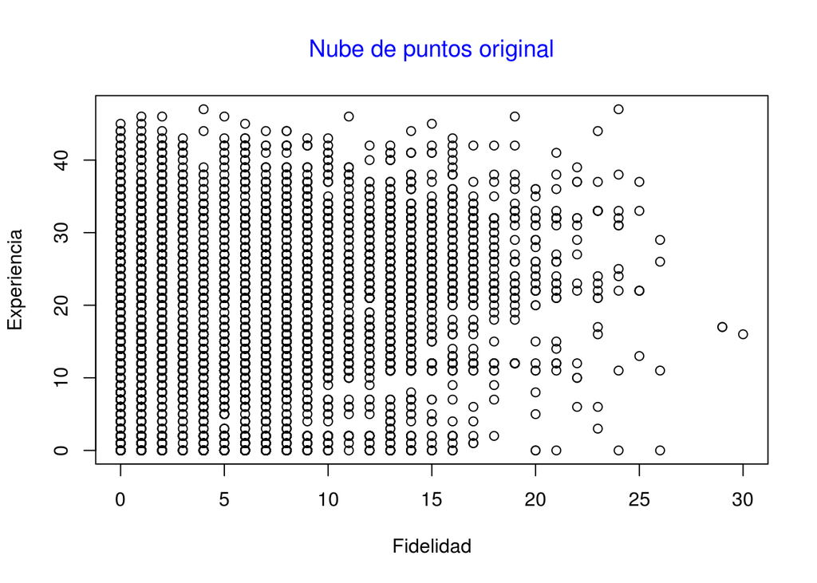

```r
plot(Cartera[c("ant_comp","ant_perm")], xlab="Fidelidad", ylab="Experiencia")
title(main="Nube de puntos original", col.main="blue", font.main=1)
```

```r
freq<-table(Cartera$sin)
freq
```

```
##
##    0    1    2    3    4    5
## 7544  487   44   10    1    2
```

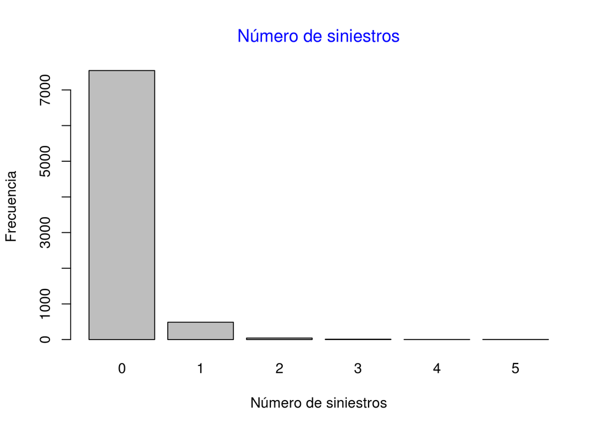

```r
barplot(freq,xlab="Número de siniestros", ylab="Frecuencia")
title(main="Número de siniestros", col.main="blue", font.main=1)
```

```r
table(Cartera$Sexo,Cartera$sin)
```

```
##
##             0    1    2    3    4    5
##   Hombre 6147  380   32    9    1    2
##   Mujer  1397  107   12    1    0    0
```

```r
prop.table(table(Cartera$Sexo,Cartera$sin))
```

```
##
##                     0            1            2            3            4
##   Hombre 0.7600148368 0.0469831850 0.0039564787 0.0011127596 0.0001236400
##   Mujer  0.1727250247 0.0132294758 0.0014836795 0.0001236400 0.0000000000
##
##                     5
##   Hombre 0.0002472799
##   Mujer  0.0000000000
```

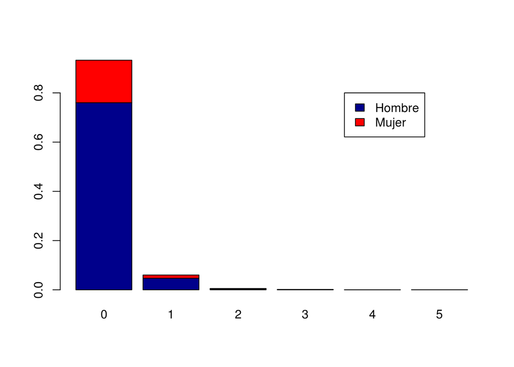

```r
barplot(prop.table(table(Cartera$Sexo,Cartera$sin)),col=c("darkblue","red"))
legend(5,0.8,c("Hombre","Mujer"),fill = c("darkblue","red"))
```

# 6 Normalización de atributos

El objetivo es utilizar la información cuantitativa relacionada con la experiencia (edad y ant_perm), con la fidelidad (ant_comp), con el vehículo (ant_veh) y con la siniestralidad (sin) para segmentar a los asegurados. Para ello, en primer lugar, definimos la base de datos con las variables cuantitativas que utilizamos en la segmentación, el resto de variables pueden servir para caracterizar los grupos formados.

```r
clus<-Cartera[,c("sin","ant_comp","ant_perm","edad","ant_veh")]
```

La varianza de las variables (o su rango de valores) utilizadas en el análisis son distintas debido a que miden características diferentes de los individuos y de su vehículo. Por ejemplo, entre las variables utilizadas en el cluster hay algunas que miden el número de años y otra que mide el número de siniestro, es decir, las escalas son muy distintas. Por tanto, antes de iniciar el proceso de segmentación es necesario normalizar los valores de las variables para eliminar el efecto de las distintas escalas de medida, esto equivale a restarles su media y dividirlas por su desviación estándar.

Para la normalización de las variables en la base de datos clus, en primer lugar copiamos su contenido en clus_norm:

```r
clus_norm<-clus
```

Remplazamos las columnas de clus_norm por las columnas de clus normalizadas:

```r
 clus_norm[,c("sin")] <- (clus$sin-mean(clus$sin))/sd(clus$sin)
 clus_norm[,c("ant_comp")] <- (clus$ant_comp-mean(clus$ant_comp))/sd(clus$ant_comp)
 clus_norm[,c("ant_perm")] <- (clus$ant_perm-mean(clus$ant_perm))/sd(clus$ant_perm)
 clus_norm[,c("edad")] <- (clus$edad-mean(clus$edad))/sd(clus$edad)
 clus_norm[,c("ant_veh")] <- (clus$ant_veh-mean(clus$ant_veh))/sd(clus$ant_veh)
```

Realizamos algunas representaciones gráficas para describir las variables normalizadas y comprobamos que la nube de puntos representada es igual a la original, lo único que cambia es la escala de los ejes.

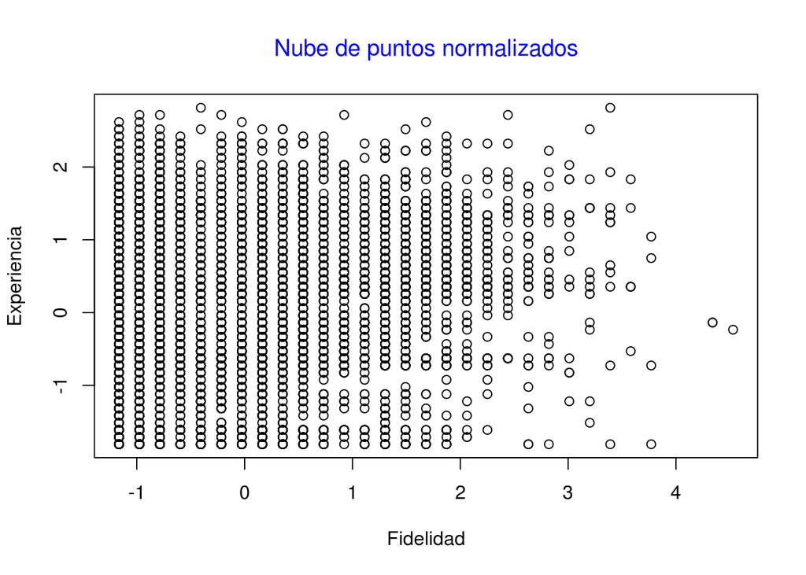

```r
#Normalizadas
plot(clus_norm[c("ant_comp","ant_perm")], xlab="Fidelidad", ylab="Experiencia")
title(main="Nube de puntos normalizados", col.main="blue", font.main=1)
```

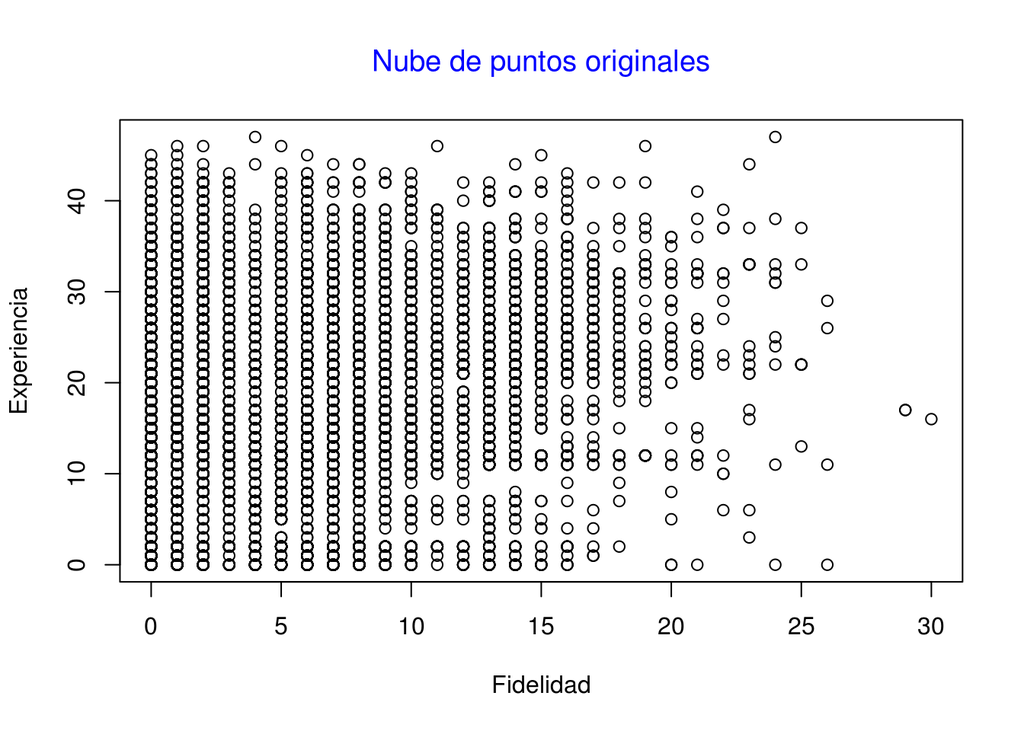

```r
#Originales
plot(clus[c("ant_comp","ant_perm")], xlab="Fidelidad", ylab="Experiencia")
title(main="Nube de puntos originales", col.main="blue", font.main=1)
```

A PARTIR DE AHORA TRABAJAMOS CON LOS DATOS NORMALIZADOS.

# 7 Agrupación jerárquica: Algoritmo aglomerativo

El algoritmo jerárquico es una técnica no supervisada de agrupación de elementos de forma iterativa. Se comienza con todos los elementos desagrupados y en cada iteración agrupa los dos elementos o grupos de elementos más próximos, utilizando un criterio de enlace, hasta que todos los elementos forman un único grupos.

## 7.1 Uso de la función hclust() para la aglomeración de elementos

Para poder agrupar los elementos es necesario establecer una métrica de distancia siendo la habitual la métrica euclídea. Dado que hay que establecer una distancia las variables deben ser numéricas por lo que si se quieren introducir variables categórica deberá crearse una variable indicador para cada una de las categorías.

```r
distances = dist(clus_norm, method = "euclidean")
```

Una vez considerada la distancia a utilizar y calculada la distancia entre los elementos a agrupar se utiliza el comando hclust de agrupación de elementos

```r
clus_norm_Jerarquico = hclust(distances, method = "ward.D")
```

## 7.2 Representación gráfica, Dendograma

Es importante señalar que no es necesario establecer de forma previa el número de conjuntos o clusters dado que el algoritmo culmina con la agrupación de todos los elementos en un único grupo.

Esta agrupación se suele representar con un gráfico llamado dendograma que muestra las agrupaciones realizadas (líneas de agrupación) y la distancia entre los elementos o grupos de elementos (altura).

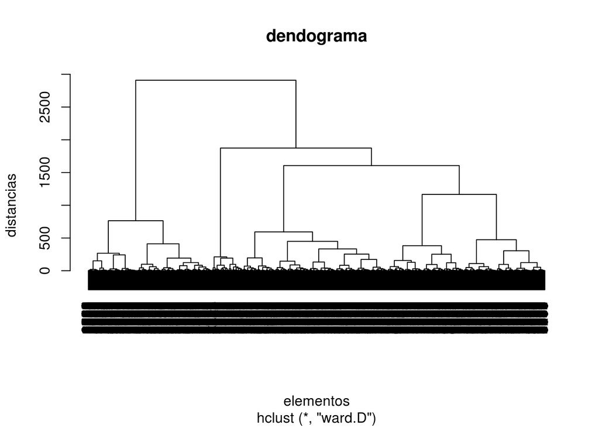

```r
plot(clus_norm_Jerarquico,main="dendograma",xlab="elementos",ylab="distancias")
```

Sobre el propio dendograma se pueden representar los grupos que se obtendrían al separar los elementos en un número k predefinido de grupos.

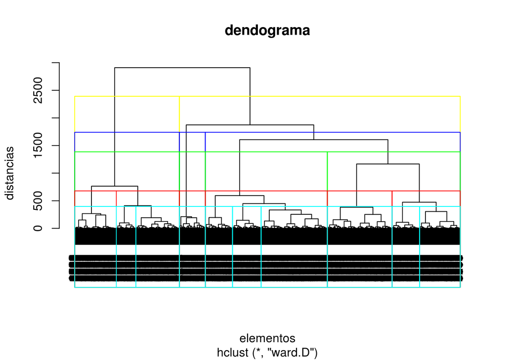

```r
plot(clus_norm_Jerarquico,main="dendograma",xlab="elementos",ylab="distancias")

rect.hclust(clus_norm_Jerarquico, k=2, border="yellow")
rect.hclust(clus_norm_Jerarquico, k=3, border="blue")
rect.hclust(clus_norm_Jerarquico, k=4, border="green")
rect.hclust(clus_norm_Jerarquico, k=6, border="red")
rect.hclust(clus_norm_Jerarquico, k=10, border="cyan")
```

## 7.3 Asignación de los clusters

Para mantener el conjunto de datos original lo primero que hacemos es crear una copia del conjunto de datos

```r
clus_jerarquico=clus
```

Una vez elegido el número de clusters, se puede asignar a cada elemento el cluster asignado. En este caso vamos a elegir 4 clusters.

```r
NumCluster=4

clus_jerarquico$clusterJerar= cutree(clus_norm_Jerarquico, k = NumCluster)
head(clus_jerarquico)
```

```
##   sin ant_comp ant_perm edad ant_veh clusterJerar
## 1   0        7        9   30       7            1
## 2   0        1        0   18       2            1
## 3   0        1       35   59       1            2
## 4   0        3       43   61       2            2
## 5   0        4        0   18       1            1
## 6   0        1       32   60       1            2
```

## 7.4 Representación de los cluster

Para poder interpretar los clusters es habitual representarlos mediante el valor medio de las variables en cada cluster.

```r
aggregate(.~clusterJerar,FUN=mean, data=clus_jerarquico)
```

```
##   clusterJerar      sin ant_comp  ant_perm     edad   ant_veh
## 1            1 0.000000 5.026412  7.886157 27.04235  6.082878
## 2            2 0.000000 6.287303 21.931492 48.23242  2.025466
## 3            3 1.137868 5.062500 17.941176 41.39154  5.345588
## 4            4 0.000000 7.157813 23.629297 48.58125 10.062891
```

```r
table(clus_jerarquico$clusterJerar)
```

```
##
##    1    2    3    4
## 2196 2788  544 2560
```

De esta manera podemos ver que hay diferencias entre los grupos. Por ejemplo el grupo 1 está formado por clientes más jovenes, mientras que el grupo 4 está formado por clientes más veteranos con mucha antigüedad en la compañía. El grupo 3, por su parte, incluye a todos los siniestrados.

## 7.5 Representación gráfica de variables por cluster

Se puede actualizar el gráfico presentado previamente que relaciona la fidelidad con la experiencia incluyendo al asignación de clusters.

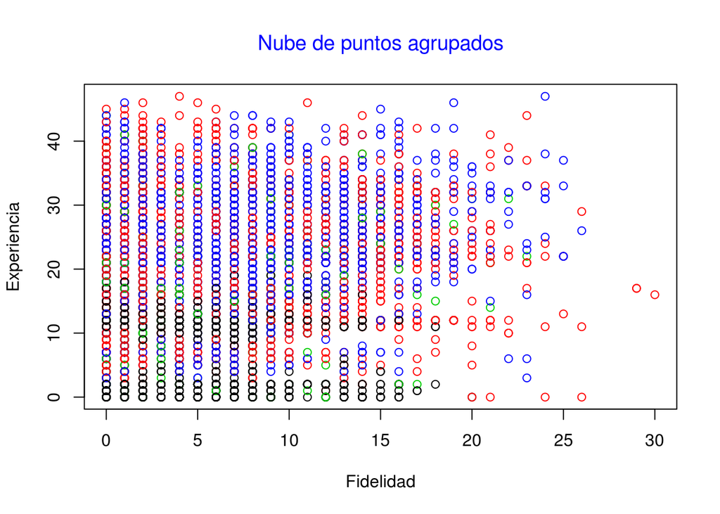

```r
plot(clus_jerarquico[c("ant_comp","ant_perm")], xlab="Fidelidad", ylab="Experiencia",col=clus_jerarquico$clusterJerar)
title(main="Nube de puntos agrupados", col.main="blue", font.main=1)
```

El grupo 1 es el color negro, el grupo 2 es el color rojo, el grupo 3 es el color verde y el grupo 4 es el color azul.

```r
palette()[1:NumCluster]
```

```
## [1] "black"  "red"    "green3" "blue"
```

# 8 Agrupación no jerárquica: Algoritmo kmeans

## 8.1 Uso de la función kmeans() para la formación de cluster (grupos o perfiles de individuos)

Los algoritmos de segmentación no supervisados, como es el kmeans(), requieren que el analista determine cuál es el número de clústers (grupos) a formar, de hecho, la función kmeans() incorpora como parámetro el número de clústers (centers=).

Para seleccionar el número de grupos podemos utilizar criterios subjetivos o criterios objetivos. Los criterios subjetivos se basan en la visualización de los resultados para determinar el número de clústers más apropiado o en la simple experiencia. A continuación, utilizamos la función kmeans() para formar 3 grupos de individuos y visualizamos algunos resultados como son: los centros de grupos (centers), la suma de cuadrados totales (totss), las sumas de cuadrados dentro de cada grupo y para todos de forma conjunta (withinss y tot.withinss) y la suma de cuadrados entre grupos (betweenss).

```r
set.seed(123)
modelo_k3<-kmeans(clus_norm,centers=3)
modelo_k3$centers
```

```
##          sin    ant_comp    ant_perm       edad     ant_veh
## 1 -0.2477649  0.09654077  0.50642861  0.5592241  0.05561796
## 2 -0.2477649 -0.15065165 -1.01405683 -1.1174220 -0.08740496
## 3  3.4359164 -0.20416192 -0.04383327 -0.0591934 -0.11480452
```

```r
modelo_k3$totss
```

```
## [1] 40435
```

```r
modelo_k3$withinss
```

```
## [1] 15907.791  5635.282  3277.135
```

```r
modelo_k3$tot.withinss
```

```
## [1] 24820.21
```

```r
modelo_k3$betweenss
```

```
## [1] 15614.79
```

## 8.2 Elección del número de clústers

Para la selección del número de clústers también existen criterios objetivos los cuales están basados en la optimización de un criterio de ajuste.

Los criterios de ajustes en el kmeans() se basan en los conceptos de sumas de cuadrados entre grupos (betweens) y dentro de grupos (withins). Hay que tener en cuenta que la suma de cuadrados entre grupos (betweenss) más las sumas de cuadrados dentro de grupos (tot.withinss) nos proporciona la suma de cuadrados totales (tots). Recordad también que las sumas de cuadrados corresponden a los numeradores de las varianzas correspondientes.

Una segmentación se considera ‘óptima’ cuando, para cada grupo, los individuos son lo más homgéneos posibles mientras que son más heterogeneos a los individuos del resto de grupos Dicha segmentación coincidirá con aquella que, teniendo un número de grupos razonable, posee una “suma de cuadrados entre grupos”(betweenss) suficientemente grande y, por tanto, una “suma de cuadrados dentro de grupos” (tot.withinss) suficientemente pequeña. Es decir, la varianza dentro de grupos debe ser reducida (individuos dentro de un mismo grupo tiene que ser similares) y la varianza entre grupos debe ser grande (individuos de distintos grupos tienen que ser distintos). También, tenemos que tener en cuenta que a medida que el número de grupos aumenta la suma de cuadrados entre aumenta y, por tanto, la suma de cuadrados dentro disminuye, por tanto, el analista a de decidir cuando el aumento de la suma de cuadrados entre o, alternativamente, la disminución de la suma de cuadrados dentro no son lo suficientemente pronunciados. Por ejemplo, comparamos los resultados para los casos de formar 2 y 3 grupos.

```r
#Suma de cuadrados entre grupos
kmeans(clus_norm,2)$betweenss
```

```
## [1] 9331.89
```

```r
kmeans(clus_norm,3)$betweenss
```

```
## [1] 12306.22
```

```r
#Suma de cuadrados dentro grupos
kmeans(clus_norm,2)$tot.withinss
```

```
## [1] 31103.11
```

```r
kmeans(clus_norm,3)$tot.withinss
```

```
## [1] 26261.3
```

```r
#Suma de cuadrados total
kmeans(clus_norm,2)$totss
```

```
## [1] 40435
```

```r
kmeans(clus_norm,3)$totss
```

```
## [1] 40435
```

A continuación, definimos el modo de obtener un gráfico que nos represente la suma de cuadrados entre grupos en función del número de grupos.

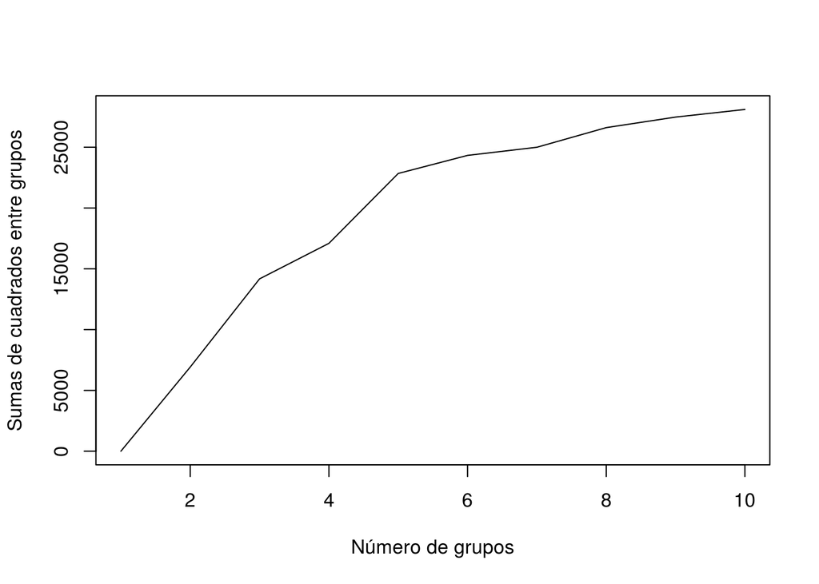

```r
set.seed(123)
bss <- kmeans(clus_norm,centers=1)$betweenss
 for (i in 2:10) bss[i] <- kmeans(clus_norm,centers=i)$betweenss

plot(1:10, bss, type="l", xlab="Número de grupos",ylab="Sumas de cuadrados entre grupos")
```

## 8.3 Asignación de los clusters

Para mantener el conjunto de datos original lo primero que hacemos es crear una copia del conjunto de datos

```r
clus_kmeans=clus
```

Una vez elegido el número de clusters, se puede asignar a cada elemento el cluster asignado. En este caso vamos a elegir 5 clusters.

```r
NumCluster=5
set.seed(123)
Modelo=kmeans(clus_norm,NumCluster)
clus_kmeans$clusterKmeans= Modelo$cluster
head(clus_kmeans)
```

```
##   sin ant_comp ant_perm edad ant_veh clusterKmeans
## 1   0        7        9   30       7             5
## 2   0        1        0   18       2             5
## 3   0        1       35   59       1             2
## 4   0        3       43   61       2             2
## 5   0        4        0   18       1             5
## 6   0        1       32   60       1             2
```

## 8.4 Representación de los cluster

Para poder interpretar los clusters es habitual representarlos mediante el valor medio de las variables en cada cluster.

```r
aggregate(.~clusterKmeans,FUN=mean, data=clus_kmeans)
```

```
##   clusterKmeans      sin  ant_comp  ant_perm     edad   ant_veh
## 1             1 0.000000 14.233119 22.659968 46.53055  4.369775
## 2             2 0.000000  2.751028 22.526725 49.23298  2.393330
## 3             3 1.137868  5.062500 17.941176 41.39154  5.345588
## 4             4 0.000000  6.260396 22.859901 48.12871 11.292079
## 5             5 0.000000  5.029651  7.306074 26.47059  5.395026
```

```r
table(clus_kmeans$clusterKmeans)
```

```
##
##    1    2    3    4    5
## 1244 2189  544 2020 2091
```

De esta manera podemos ver que hay diferencias entre los grupos. Por ejemplo el grupo 5 está formado por clientes más jovenes, mientras que el grupo 1 está formado por clientes con mucha antigüedad en la compañía. El grupo 3, por su parte, incluye a todos los siniestrados y el grupo 4 recoge a asegurados con una antiguedad del vehículo superior.

## 8.5 Representación gráfica de los clústers

Se puede actualizar el gráfico presentado previamente que relaciona la fidelidad con la experiencia incluyendo al asignación de clusters.

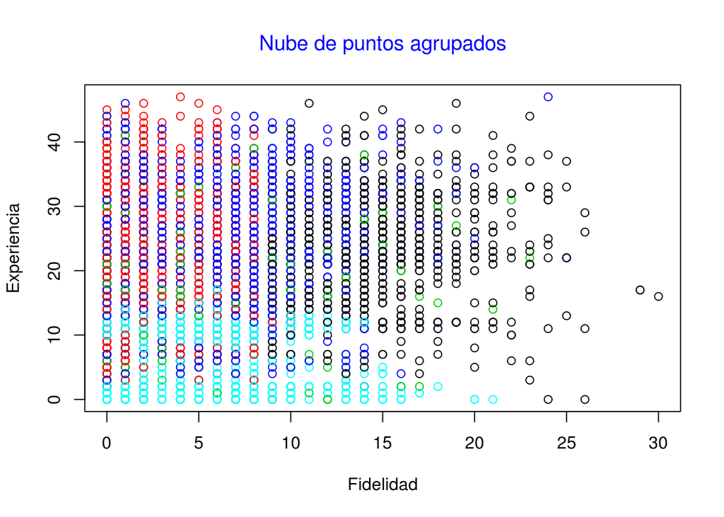

```r
plot(clus_kmeans[c("ant_comp","ant_perm")], xlab="Fidelidad", ylab="Experiencia",col=clus_kmeans$clusterKmeans)
title(main="Nube de puntos agrupados", col.main="blue", font.main=1)
```

El grupo 1 es el color negro, el grupo 2 es el color rojo, el grupo 3 es el color verde, el grupo 4 es el color azul y el grupo 5 es el de color cyan.

```r
palette()[1:NumCluster]
```

```
## [1] "black"  "red"    "green3" "blue"   "cyan"
```

# 9 Ejercicios PEC2

## 9.1 Ejercicio 1

En el apartado de *representación gráfica de variables por cluster* del algorítmo jerárquico se ha dibujado una nube de puntos en función a la fidelidad y la experiencia. Ahora queremos conocer la relación entre la antiguedad del permiso de conducir y la edad representando con 4 colores los clusters construidos con el algorítmo jerárquico.

## 9.2 Respuesta 1

Para ello cojeremos del dataframe edad y ant_perm y lo mostraremos.

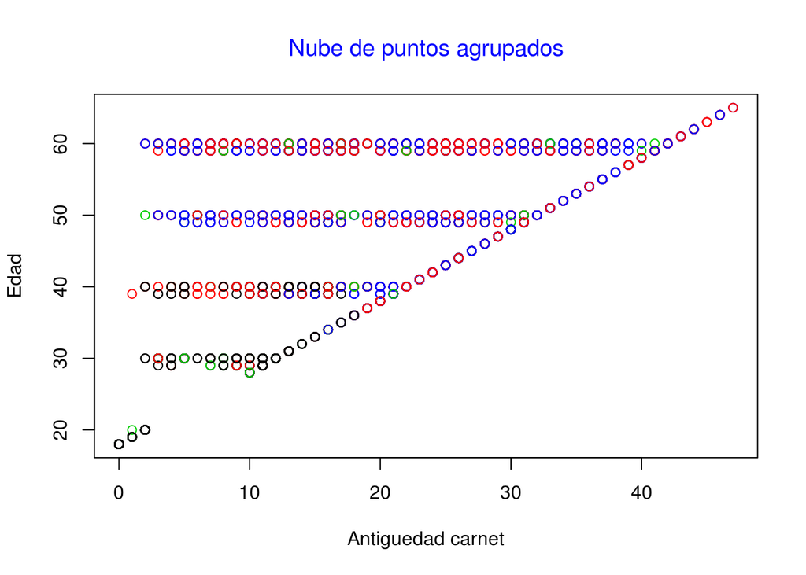

```r
# Pon aquí los comandos de R en caso de ser necesario.
plot(clus_jerarquico[c("ant_perm","edad")], xlab="Antiguedad carnet", ylab="Edad",col=clus_jerarquico$clusterJerar)
title(main="Nube de puntos agrupados", col.main="blue", font.main=1)
```

## 9.3 Ejercicio 2

Construir una clusterización en 7 clusters utilizando el algoritmo kmeans. Represente los clusters tal y como se ha hecho en el apartado *representación de los cluster* y describa alguno de los grupos

## 9.4 Respuesta 2

Vemos como el ultimo grupo sigue siendo el de los jovenes, edad corta, poca experiencia, en el lado contrario, vemos el grupo 4, el cual con 49 años de media, vehiculo viejo, y muchos años de experiencia y siendo fieles.

```r
# Pon aquí los comandos de R en caso de ser necesario.
NumCluster=7
set.seed(123)
Modelo=kmeans(clus_norm,NumCluster)
clus_kmeans$clusterKmeans= Modelo$cluster
head(clus_kmeans)
```

```
##   sin ant_comp ant_perm edad ant_veh clusterKmeans
## 1   0        7        9   30       7             7
## 2   0        1        0   18       2             7
## 3   0        1       35   59       1             2
## 4   0        3       43   61       2             2
## 5   0        4        0   18       1             7
## 6   0        1       32   60       1             2
```

```r
aggregate(.~clusterKmeans,FUN=mean, data=clus_kmeans)
```

```
##   clusterKmeans         sin  ant_comp  ant_perm     edad   ant_veh
## 1             1 0.000000000 13.445783 21.016682 45.65709  2.970343
## 2             2 0.000000000  3.212199 31.247423 53.65292  4.560997
## 3             3 1.138632163  4.983364 17.872458 41.33272  5.288355
## 4             4 0.003307607 12.186329 26.092613 49.37927 11.962514
## 5             5 0.000000000  4.205843 16.504648 42.14210 10.550465
## 6             6 0.000000000  2.263804 16.218814 43.94615  1.733470
## 7             7 0.000000000  5.613764  5.393961 23.83638  4.927669
```

## 9.5 Ejercicio 3

En el apartado de *asignacion de los clusters* del algoritmo kmeans aparece el código set.seed(123). Vuelva a realizar una agrupación kmeans con 5 clusters pero utilizando el código set.seed(12345). ¿Obtenemos el mismo resultado?, compare los resultados. ¿Cuál es el motivo por el que ocurre esto?

## 9.6 Respuesta 3

No se obtiene el mismo resultado ya que la semilla es diferente, la semilla es una manera de “barajar” que tiene el algoritmo, por ejemplo para ver donde empiezan los centroides. En este caso la semilla es una manera de asegurarse la reproducibilidad de los reultados, para que, en caso de que una persona haga el mismo algoritmo, la aleatoriedad no sea un factor diferenciador a la hora de comparar.

```r
# Pon aquí los comandos de R en caso de ser necesario.
NumCluster=5
set.seed(12345)
Modelo=kmeans(clus_norm,NumCluster)
clus_kmeans$clusterKmeans= Modelo$cluster
head(clus_kmeans)
```

```
##   sin ant_comp ant_perm edad ant_veh clusterKmeans
## 1   0        7        9   30       7             1
## 2   0        1        0   18       2             4
## 3   0        1       35   59       1             5
## 4   0        3       43   61       2             5
## 5   0        4        0   18       1             4
## 6   0        1       32   60       1             5
```

## 9.7 Ejercicio 4

Al presentar los datos obtenidos por el algoritmos jerárquico para 4 cluster a los responsables del negocio, nos preguntan si el reparto de hombres y mujeres entre los clusters es homogéneo o hay alguno en el que haya mayoría. Calcule el porcentaje de hombres y mujeres que hay en cada cluster.

## 9.8 Respuesta 4

Para ello añadiremos a nuestro dataframe la columna de sexo y despues con la libreria dplyr calcularemos el % de distribuion de sexo por cluster. Como vemos la distribucion no es uniforme, si es verdad que las mujeres estan en minoria en todos los grupos, pero tenemos el primer cluster con un 23 % de mujeres y el ultimo cluster con un 13 %, una diferencia del 10 % es muy grade, podemos decir que ladistribucion no es uniforme. Por ultimo haremos una representacion grafica que hara que visualmente se pueda apreciar mejor la distribucion. Para ello utilizaremos 2 librerias, reshape que usaremos para que las 2 columnas de % se queden en una sola columna y ggplot para representarlo graficamente.

```r
# Pon aquí los comandos de R en caso de ser necesario.
library(dplyr)
library(reshape2)
library(ggplot2)

clus_jerarquico$sexo <- Cartera$Sexo

clusters_por_sexo <- clus_jerarquico %>%
                        group_by(clusterJerar) %>%
                        summarise(numero_mujeres = sum(sexo == 'Mujer'),
                                  numero_hombres = sum(sexo == 'Hombre'),
                                  total = sum(sexo == 'Mujer' | sexo == 'Hombre'),
                                  prcnt_mujeres = numero_mujeres / total * 100,
                                  prcnt_hombres = numero_hombres / total * 100) %>%
                        select(clusterJerar, prcnt_mujeres, prcnt_hombres)

clusters_por_sexo
```

```
## # A tibble: 4 x 3
##   clusterJerar prcnt_mujeres prcnt_hombres
##          <int>         <dbl>         <dbl>
## 1            1          23.1          76.9
## 2            2          19.8          80.2
## 3            3          22.1          77.9
## 4            4          13.1          86.9
```

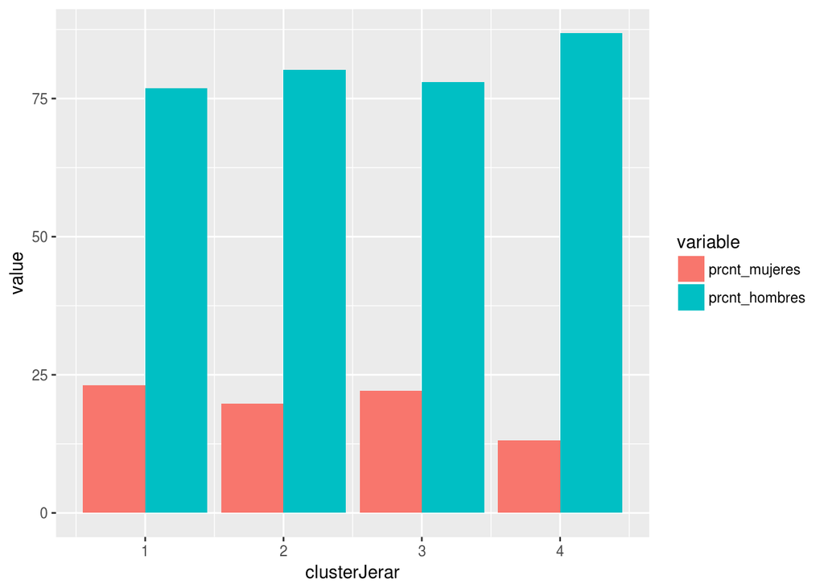

```r
clusters_por_sexo.long<-melt(clusters_por_sexo, id.vars = "clusterJerar")
ggplot(clusters_por_sexo.long,aes(clusterJerar,value,fill=variable))+
     geom_bar(stat="identity",position="dodge")
```

## 9.9 Ejercicio 5

En el apartado sobre la *elección del número de clústers* del algoritmo kmeans se muestra un gráfico que toma como variable referencia la suma de cuadrados entre ‘$betweenss’.

Dibuja un gráfico equivalente, tomando como referencia la suma de cuadrados en ‘$tot.withinss’ e interpreta el resultado proponiendo un número de clústers adecuado para el juego de datos.

## 9.10 Respuesta 5

Nos interesa encontrar el punto en el que la distancia es muy pequeña, en este caso es a la inversa que el anterior. Se vuelve a escoger 5 clusters.

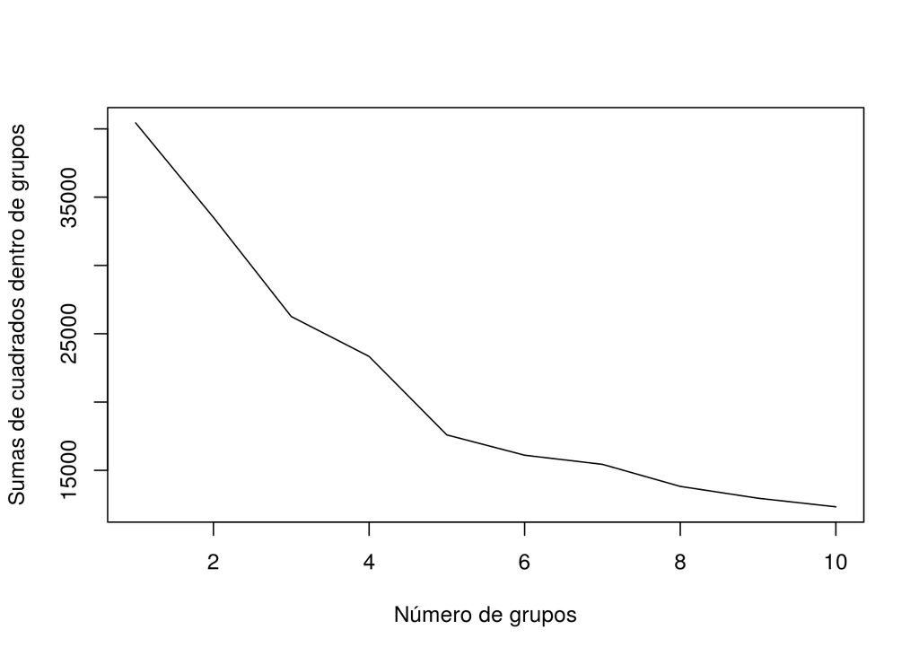

```r
# Pon aquí los comandos de R en caso de ser necesario.
set.seed(123)
bss <- kmeans(clus_norm,centers=1)$tot.withinss
 for (i in 2:10) bss[i] <- kmeans(clus_norm,centers=i)$tot.withinss

plot(1:10, bss, type="l", xlab="Número de grupos",ylab="Sumas de cuadrados dentro de grupos")
```

## 9.11 Ejercicio 6

Al presentar los resultados al responsable del negocio, este nos indica que le gustaría incluir la variable sri (Urbano, No urbano) en el análisis. ¿Es posible incluirlo en la segmentación como una variable más?. En caso afirmativo, realizar dicha inclusión y construir una segmentación kmeans con k=4. En caso contrario, indicar el motivo por el que no se puede incluir.

## 9.12 Respuesta 6

```r
# Pon aquí los comandos de R en caso de ser necesario.

clus<-Cartera[,c("sin","ant_comp","ant_perm","edad","ant_veh","sri")]

levels(clus$sri) <- c(0,1)
clus$sri <- as.numeric(clus$sri)

clus_norm<-clus

clus_norm[,c("sin")] <- (clus$sin-mean(clus$sin))/sd(clus$sin)
clus_norm[,c("ant_comp")] <- (clus$ant_comp-mean(clus$ant_comp))/sd(clus$ant_comp)
clus_norm[,c("ant_perm")] <- (clus$ant_perm-mean(clus$ant_perm))/sd(clus$ant_perm)
clus_norm[,c("edad")] <- (clus$edad-mean(clus$edad))/sd(clus$edad)
clus_norm[,c("ant_veh")] <- (clus$ant_veh-mean(clus$ant_veh))/sd(clus$ant_veh)
clus_norm[,c("sri")] <- (clus$sri-mean(clus$sri))/sd(clus$sri)

clus_kmeans4=clus

NumCluster=4
set.seed(123)
Modelo4=kmeans(clus_norm,NumCluster)
clus_kmeans4$clusterKmeans= Modelo4$cluster
head(clus_kmeans4)
```

```
##   sin ant_comp ant_perm edad ant_veh sri clusterKmeans
## 1   0        7        9   30       7   1             2
## 2   0        1        0   18       2   2             2
## 3   0        1       35   59       1   2             1
## 4   0        3       43   61       2   2             1
## 5   0        4        0   18       1   1             2
## 6   0        1       32   60       1   1             4
```

```r
aggregate(.~clusterKmeans,FUN=mean, data=clus_kmeans4)
```

```
##   clusterKmeans      sin ant_comp  ant_perm     edad  ant_veh      sri
## 1             1 0.000000 6.701701 20.468818 45.27649 5.982992 2.000000
## 2             2 0.000000 5.292574  6.582356 25.67728 5.506979 1.176438
## 3             3 1.137868 5.062500 17.941176 41.39154 5.345588 1.316176
## 4             4 0.000000 6.371387 23.187861 48.67572 6.122543 1.000000
```